# ITS2 metabarcoding dada2 workflow

B. Karina Montero

2023-11-22

B. Karina Montero Modified from: https://benjjneb.github.io/dada2/ITS_workflow.html

## LOAD LIBRARIES

```r
rm(list = ls())

library(devtools)
library(dada2)
packageVersion("dada2")
```

```
## [1] '1.28.0'
```

```r
library(ShortRead)
library(ggplot2)
library(dplyr)
library(plyr)
library(tidyr)
library(stringr)
library(forcats)
```

## WORKING DIRECTORIES

```r
source("/home/kari/Dropbox/PollenUCR/01_scripts/UCR_workingDirectories.R")
```

## I. LOAD & CHECK DATA

### Directory containing the fastq files

```r
ITS2_files <- sort(list.files(fastaDir, full.names = TRUE))
head(list.files(fastaDir))
```

```
## [1] "04042023-EMo23-SB001_S84_L001_R1_001.fastq.gz"
## [2] "04042023-EMo23-SB001_S84_L001_R2_001.fastq.gz"
## [3] "04042023-EMo23-SB002_S85_L001_R1_001.fastq.gz"
## [4] "04042023-EMo23-SB002_S85_L001_R2_001.fastq.gz"
## [5] "04042023-EMo23-SB003_S86_L001_R1_001.fastq.gz"
## [6] "04042023-EMo23-SB003_S86_L001_R2_001.fastq.gz"
```

### Inspect read quality profiles

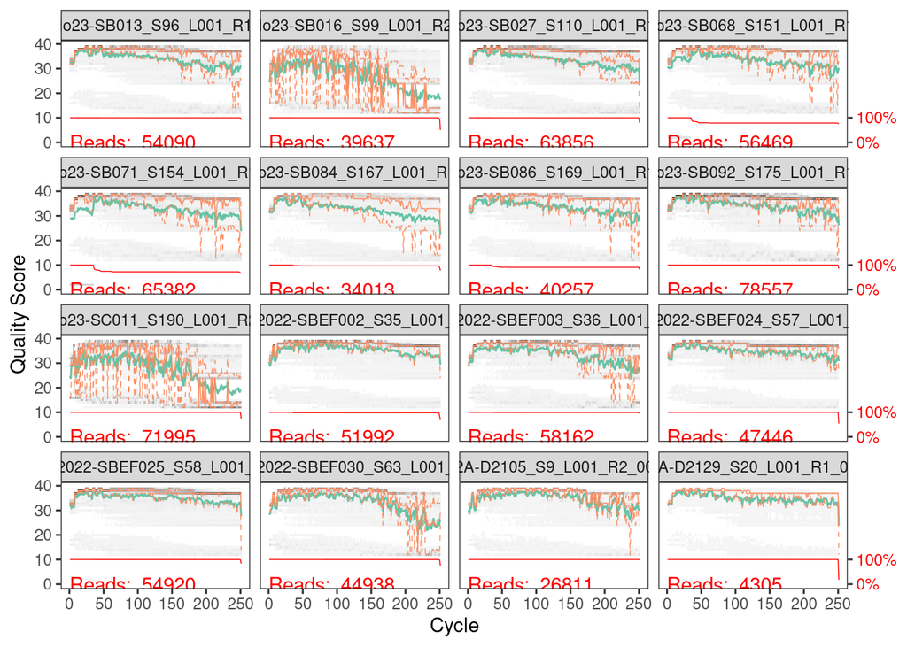

```r
some_files <- sample(1:328, 16, replace = FALSE)
plotQualityProfile(ITS2_files[c(some_files)])
```

## II. REMOVE PRIMERS

Set patterns to discriminate forward and reverse read files

```r
file_pattern <- c(F = "_R1_001.fastq", R = "_R2_001.fastq")
fas_Fs_raw <- sort(list.files(fastaDir, pattern = file_pattern["F"],
    full.names = TRUE))
fas_Rs_raw <- sort(list.files(fastaDir, pattern = file_pattern["R"],
    full.names = TRUE))
```

Primer sequences

For pollen library preparation, a fragment of the ITS2 gene of around 450 bp was amplified using the following primers (Cheng et al 2016 MolEcolRes):

```r
FWD <- "YGACTCTCGGCAACGGATA"
REV <- "CCGCTTAKTGATATGCTTAAA"
```

Verify the presence and orientation of these primers in the data.

```r
allOrients <- function(primer) {
    # Create all orientations of the input
    # sequence
    require(Biostrings)
    dna <- DNAString(primer)  # The Biostrings works w/ DNAString objects rather than character vectors
    orients <- c(Forward = dna, Complement = complement(dna),
        Reverse = reverse(dna), RevComp = reverseComplement(dna))
    return(sapply(orients, toString))  # Convert back to character vector
}

FWD_orients <- allOrients(FWD)
REV_orients <- allOrients(REV)

# The presence of ambiguous bases (Ns) in
# the sequencing reads makes accurate
# mapping of short primer sequences
# difficult. Next we are going to
# “pre-filter” the sequences just to remove
# those with Ns, but perform no other
# filtering.

# Put N-filterd files in filtN/ subdirectory
fas_Fs_filtN <- file.path(fastaDir, "filtN", basename(fas_Fs_raw))
fas_Rs_filtN <- file.path(fastaDir, "filtN", basename(fas_Rs_raw))

filterAndTrim(fas_Fs_raw, fas_Fs_filtN, fas_Rs_raw,
    fas_Rs_filtN, maxN = 0, multithread = 6)

## Ran out of memory when using multithread
## = TRUE solution: specify number of cores
## (bellow max)
```

Count the number of times the primers appear in the forward and reverse read, while considering all possible primer orientations.

```r
primerHits <- function(primer, fn) {
    # Counts number of reads in which the
    # primer is found
    nhits <- vcountPattern(primer, sread(readFastq(fn)),
        fixed = FALSE)
    return(sum(nhits > 0))
}

primer_count <- rbind(FWD.ForwardReads_ITS = sapply(FWD_orients,
    primerHits, fn = fas_Fs_filtN[[1]]), FWD.ReverseReads_ITS = sapply(FWD_orients,
    primerHits, fn = fas_Rs_filtN[[1]]), REV.ForwardReads_ITS = sapply(REV_orients,
    primerHits, fn = fas_Fs_filtN[[1]]), REV.ReverseReads_ITS = sapply(REV_orients,
    primerHits, fn = fas_Rs_filtN[[1]]))
primer_count
```

```
##                      Forward Complement Reverse RevComp
## FWD.ForwardReads_ITS       0          0       0      46
## FWD.ReverseReads_ITS   52171          0       0       0
## REV.ForwardReads_ITS   66032          0       0       0
## REV.ReverseReads_ITS     128          0       0      32
```

```r
FWD_RC <- dada2:::rc(FWD)
REV_RC <- dada2:::rc(REV)

path_cut <- file.path(fastaDir, "cutadapt")
if(!dir.exists(path_cut)) dir.create(path_cut)

fas_Fs_cut <- file.path(path_cut, basename(fas_Fs_filtN))
fas_Rs_cut <- file.path(path_cut, basename(fas_Rs_filtN))

# Trim REV and the reverse-complement of FWD off of R1 (forward reads)
R1_flags <- paste(paste("-g", REV, collapse = " "), paste("-a", FWD_RC, collapse = " "))

# Trim FWD and the reverse-complement of REV off of R2 (forward reads)
R2_flags <- paste(paste("-G", FWD, collapse = " "), paste("-A", REV_RC, collapse = " "))

cutadapt <- "/home/kari/miniconda3/envs/cutadaptenv/bin/cutadapt" # Path to the executable

for(i in seq_along(fas_Fs_filtN)) {
  #cat("Processing", "-----------", i, "/", length(fas_Fs_filtN), "-----------\n")
  system2(cutadapt, args = c(R1_flags, R2_flags,
                             "-m 50",
                             "--cores 8", # Use 0 to auto-detect.
                             "-n 2", # required to remove FWD and REV from read
                             "-o", fas_Fs_cut[i], "-p", fas_Rs_cut[i],
                             fas_Fs_filtN[i], fas_Rs_filtN[i]))
}

primer_count <- rbind(FWD.ForwardReads_ITS = sapply(FWD_orients, primerHits, fn = fas_Fs_cut[[1]]),
    FWD.ReverseReads_ITS = sapply(FWD_orients, primerHits, fn = fas_Rs_cut[[1]]),
    REV.ForwardReads_ITS = sapply(REV_orients, primerHits, fn = fas_Fs_cut[[1]]),
    REV.ReverseReads_ITS = sapply(REV_orients, primerHits, fn = fas_Rs_cut[[1]]))
primer_count
```

```
##                      Forward Complement Reverse RevComp
## FWD.ForwardReads_ITS       0          0       0       0
## FWD.ReverseReads_ITS       0          0       0       0
## REV.ForwardReads_ITS       0          0       0       0
## REV.ReverseReads_ITS     128          0       0       0
```

Summary report to keep track of primer trimming step

```r
directories <- c(fastaDir, path_cut)
d <- directories[1]
filenames <- list.files(directories)
f <- filenames[1]
reads_report <- list()
widths <- list()
j <- 1
out <- data.frame()

for (d in directories) {
    get_path <- d
    name_path <- sub(".*/", "", d)
    filenames <- list.files(get_path, pattern = ".fastq")
    for (f in filenames) {
        infile <- readFastq(get_path, f)
        f1 <- sub("_001.*", "", f)
        file_biostring <- sread(infile)
        reads_report[[j]] <- data.frame(sampleID = f1,
            n_reads = length(file_biostring@ranges@width),
            directory = name_path)
        j = j + 1
        out <- data.frame(Reduce(rbind, reads_report))
    }
}

out_2 <- out


# Wide to long format

reads_df <- out %>%
    pivot_wider(names_from = directory, values_from = n_reads) %>%
    dplyr::rename(raw = "02_fastq_files") %>%
    as.data.frame
reads_df$sampleID <- sub("\\_.*", "", reads_df$sampleID)
head(reads_df)
```

```
##               sampleID   raw cutadapt
## 1 04042023-EMo23-SB001 69497    69332
## 2 04042023-EMo23-SB001 69497    69332
## 3 04042023-EMo23-SB002 70512    70354
## 4 04042023-EMo23-SB002 70512    70354
## 5 04042023-EMo23-SB003 52284    52140
## 6 04042023-EMo23-SB003 52284    52140
```

```r
# save file
write.csv(reads_df, paste0(outputDir, "/01_dada2/ITS2_track_cutadapt.csv"))
```

## III. FILTER AND TRIM

```r
path_cut <- paste0(fastaDir, "/cutadapt")

fas_Fs_cut <- sort(list.files(path_cut, pattern = file_pattern["F"],
    full.names = TRUE))
fas_Rs_cut <- sort(list.files(path_cut, pattern = file_pattern["R"],
    full.names = TRUE))

sample_names <- sapply(strsplit(basename(fas_Fs_cut),
    "_"), function(x) x[1])

ITS2_cut <- sort(list.files(path_cut, full.names = TRUE))
```

Inspect read quality profiles

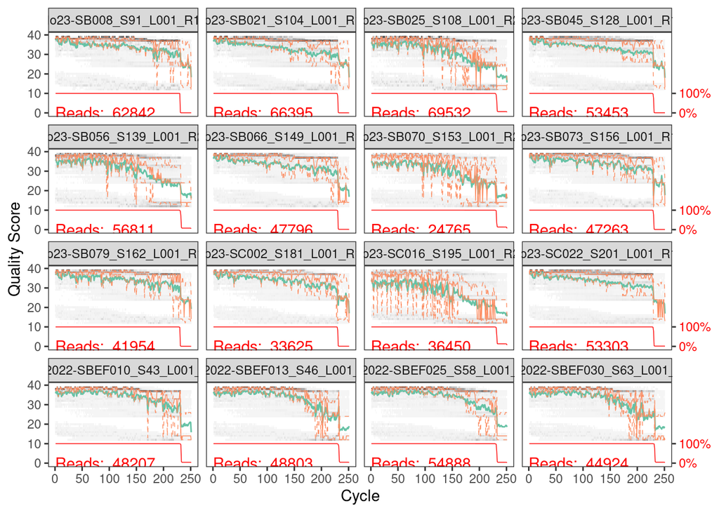

```r
some_files <- sample(1:374, 16, replace = FALSE)
plotQualityProfile(ITS2_cut[c(some_files)])
```

```r
fas_Fs_filtered <- file.path(fastaDir, "filtered",
    basename(fas_Fs_cut))
fas_Rs_filtered <- file.path(fastaDir, "filtered",
    basename(fas_Rs_cut))
all.equal(basename(fas_Fs_raw), basename(fas_Fs_filtered))
```

```
## [1] TRUE
```

```r
names(fas_Fs_filtered) <- sample_names
names(fas_Rs_filtered) <- sample_names
```

Standard filtering paraments: maxN=0 (DADA2 requires sequences contain no Ns), truncQ = 2, rm.phix = TRUE and maxEE=2. The maxEE parameter sets the maximum number of “expected errors” allowed in a read, which is a better filter than simply averaging quality scores.

```r
filter_trim <- filterAndTrim(fas_Fs_cut, fas_Fs_filtered,
    fas_Rs_cut, fas_Rs_filtered, minLen = 50,
    maxLen = 600, maxN = 0, maxEE = c(2, 2), truncQ = 2,
    rm.phix = TRUE, multithread = 6, verbose = TRUE)
head(filter_trim)
```

```
##                                               reads.in reads.out
## 04042023-EMo23-SB001_S84_L001_R1_001.fastq.gz    69332     23866
## 04042023-EMo23-SB002_S85_L001_R1_001.fastq.gz    70354     32552
## 04042023-EMo23-SB003_S86_L001_R1_001.fastq.gz    52140     22802
## 04042023-EMo23-SB004_S87_L001_R1_001.fastq.gz    80372     38832
## 04042023-EMo23-SB005_S88_L001_R1_001.fastq.gz    62702     32277
## 04042023-EMo23-SB006_S89_L001_R1_001.fastq.gz    76021     35139
```

## IV. DADA2

Learn error rates

```r
error_F <- learnErrors(fas_Fs_filtered, multithread = TRUE,
    randomize = TRUE)
```

```
## 103569426 total bases in 450707 reads from 19 samples will be used for learning the error rates.
```

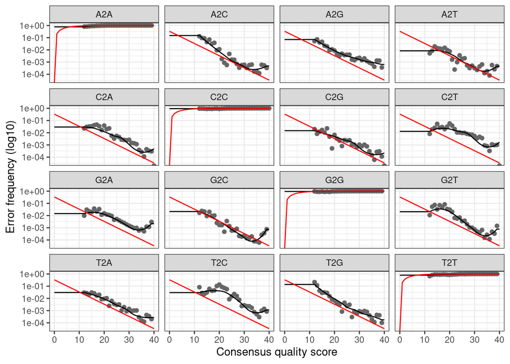

```r
plotErrors(error_F, nominalQ = TRUE)
```

```r
error_R <- learnErrors(fas_Rs_filtered, multithread = TRUE,
    randomize = TRUE)
```

```
## 105482475 total bases in 455894 reads from 21 samples will be used for learning the error rates.
```

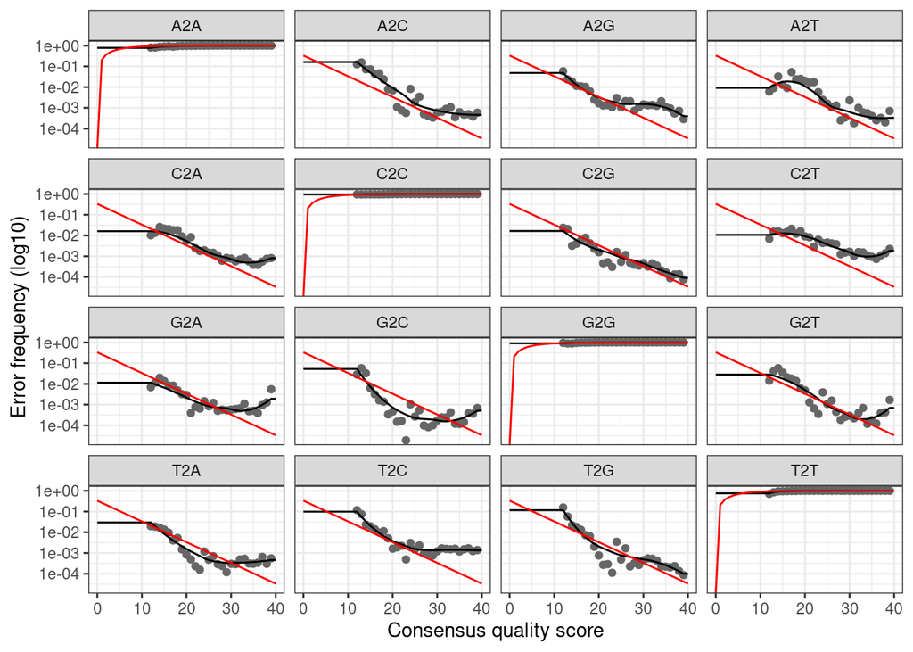

```r
plotErrors(error_R, nominalQ = TRUE)
```

### DEREPLICATION, SAMPLE INFERENCE & MERGE PAIRED READS

```r
merged_list <- vector("list", length(sample_names))
names(merged_list) <- sample_names

for (i in sample_names) {
    cat("Processing -------", which(sample_names ==
        i), "/", length(sample_names), "-------",
        i, "\n")
    derep_Fs <- derepFastq(fas_Fs_filtered[[i]],
        verbose = TRUE)
    derep_Rs <- derepFastq(fas_Rs_filtered[[i]],
        verbose = TRUE)
    dds_Fs <- dada(derep_Fs, err = error_F, multithread = TRUE,
        verbose = TRUE)
    dds_Rs <- dada(derep_Rs, err = error_R, multithread = TRUE,
        verbose = TRUE)
    merged_list[[i]] <- mergePairs(dds_Fs, derep_Fs,
        dds_Rs, derep_Rs, verbose = TRUE)
}
```

```
## Processing ------- 1 / 164 ------- 04042023-EMo23-SB001
## Sample 1 - 23866 reads in 2461 unique sequences.
## Sample 1 - 23866 reads in 11883 unique sequences.
## Processing ------- 2 / 164 ------- 04042023-EMo23-SB002
## Sample 1 - 32552 reads in 4036 unique sequences.
## Sample 1 - 32552 reads in 13768 unique sequences.
## Processing ------- 3 / 164 ------- 04042023-EMo23-SB003
## Sample 1 - 22802 reads in 2673 unique sequences.
## Sample 1 - 22802 reads in 10779 unique sequences.
## Processing ------- 4 / 164 ------- 04042023-EMo23-SB004
## Sample 1 - 38832 reads in 3515 unique sequences.
## Sample 1 - 38832 reads in 14292 unique sequences.
## Processing ------- 5 / 164 ------- 04042023-EMo23-SB005
## Sample 1 - 32277 reads in 1881 unique sequences.
## Sample 1 - 32277 reads in 9322 unique sequences.
## Processing ------- 6 / 164 ------- 04042023-EMo23-SB006
## Sample 1 - 35139 reads in 4106 unique sequences.
## Sample 1 - 35139 reads in 14148 unique sequences.
## Processing ------- 7 / 164 ------- 04042023-EMo23-SB007
## Sample 1 - 31427 reads in 2053 unique sequences.
## Sample 1 - 31427 reads in 9301 unique sequences.
## Processing ------- 8 / 164 ------- 04042023-EMo23-SB008
## Sample 1 - 29100 reads in 2094 unique sequences.
## Sample 1 - 29100 reads in 9625 unique sequences.
## Processing ------- 9 / 164 ------- 04042023-EMo23-SB009
## Sample 1 - 14720 reads in 2196 unique sequences.
## Sample 1 - 14720 reads in 7294 unique sequences.
## Processing ------- 10 / 164 ------- 04042023-EMo23-SB010
## Sample 1 - 26567 reads in 3241 unique sequences.
## Sample 1 - 26567 reads in 10467 unique sequences.
## Processing ------- 11 / 164 ------- 04042023-EMo23-SB011
## Sample 1 - 25845 reads in 3179 unique sequences.
## Sample 1 - 25845 reads in 9183 unique sequences.
## Processing ------- 12 / 164 ------- 04042023-EMo23-SB012
## Sample 1 - 27086 reads in 2194 unique sequences.
## Sample 1 - 27086 reads in 8751 unique sequences.
## Processing ------- 13 / 164 ------- 04042023-EMo23-SB013
## Sample 1 - 27610 reads in 5542 unique sequences.
## Sample 1 - 27610 reads in 12895 unique sequences.
## Processing ------- 14 / 164 ------- 04042023-EMo23-SB014
```

[output cut: 437 more lines]

```
## Processing ------- 160 / 164 ------- ENES2022A-D2145
## Sample 1 - 14617 reads in 1521 unique sequences.
## Sample 1 - 14617 reads in 2504 unique sequences.
## Processing ------- 161 / 164 ------- ENES2022A-D2153
## Sample 1 - 17510 reads in 1614 unique sequences.
## Sample 1 - 17510 reads in 2315 unique sequences.
## Processing ------- 162 / 164 ------- ENES2022A-D2161
## Sample 1 - 17672 reads in 1807 unique sequences.
## Sample 1 - 17672 reads in 2080 unique sequences.
## Processing ------- 163 / 164 ------- ENES2022B-D2146
## Sample 1 - 17084 reads in 2403 unique sequences.
## Sample 1 - 17084 reads in 2760 unique sequences.
## Processing ------- 164 / 164 ------- ENES2022B-D2154
## Sample 1 - 11018 reads in 1164 unique sequences.
## Sample 1 - 11018 reads in 1486 unique sequences.
```

### BUILD SEQUENCE TABLE

```r
seqtab <- makeSequenceTable(merged_list)
dim(seqtab)
```

```
## [1]  164 7408
```

```r
seqtab_df <- data.frame(table(nchar(getSequences(seqtab))))
colnames(seqtab_df) <- c("Length", "Freq")
write.csv(seqtab_df, paste0(outputDir, "/01_dada2/seqtab_length_distrib.csv"))

# Plot sequence length distribution
seqtab_df <- read.csv(paste0(outputDir, "/01_dada2/seqtab_length_distrib.csv"))
str(seqtab_df)
```

```
## 'data.frame':    178 obs. of  3 variables:
##  $ X     : int  1 2 3 4 5 6 7 8 9 10 ...
##  $ Length: int  56 63 69 70 84 100 103 106 107 119 ...
##  $ Freq  : int  1 1 1 2 1 1 3 1 2 1 ...
```

[figure not shown]

```r
freq_seqtab_df <- as.vector(rep(seqtab_df$Length,
    seqtab_df$Freq))
hist(freq_seqtab_df, breaks = 50, xlab = "Length",
    main = "Sequence length distribution \n (n_samples= 187, n_seqs = 8086)")
```

### REMOVE CHIMERAS

```r
seqtab_nochim <- removeBimeraDenovo(seqtab, method = "consensus",
    multithread = TRUE, verbose = TRUE)

dim(seqtab_nochim)
```

```
## [1]  164 2937
```

[figure not shown]

```r
nochim_df <- data.frame(table(nchar(getSequences(seqtab_nochim))))
colnames(nochim_df) <- c("Length", "Freq")

write.csv(nochim_df, paste0(outputDir, "/01_dada2/nochim_length_distrib.csv"))

# Plot sequence length distribution chimera
# filtered data
nochim_df <- read.csv(paste0(outputDir, "/01_dada2/nochim_length_distrib.csv"))
freq_nochim_df <- as.vector(rep(nochim_df$Length,
    nochim_df$Freq))
hist(freq_nochim_df, breaks = 50, xlab = "Length",
    main = "Non-chimeric sequence length distribution \n (n_samples= 187, n_seqs = 3306)")
```

### TRACK READS THROUGH THE PIPELINE

```r
track <- cbind(filter_trim, rowSums(seqtab), rowSums(seqtab_nochim))
colnames(track) <- c("cutadapt", "filtered", "merged",
    "nonchim")
rownames(track) <- sample_names
track <- tibble::rownames_to_column(as.data.frame(track),
    "sampleID")
head(track)
```

```
##               sampleID cutadapt filtered merged nonchim
## 1 04042023-EMo23-SB001    69332    23866  22865   22021
## 2 04042023-EMo23-SB002    70354    32552  30839   30545
## 3 04042023-EMo23-SB003    52140    22802  20936   20490
## 4 04042023-EMo23-SB004    80372    38832  37584   37477
## 5 04042023-EMo23-SB005    62702    32277  32028   31952
## 6 04042023-EMo23-SB006    76021    35139  31950   29832
```

```r
# add column with raw read counts
track_raw <- read.csv(paste0(outputDir, "/01_dada2/ITS2_track_cutadapt.csv"))
track_raw <- track_raw %>%
    select("sampleID", "raw")

# join datasets to update the read count
track_update <- left_join(track_raw, track, by = "sampleID")
track_update$run <- ifelse(grepl("220822", track_update$sampleID),
    "segundo-envio", ifelse(grepl("04042023",
        track_update$sampleID), "tercer-envio",
        ifelse(grepl("ENES2022A", track_update$sampleID),
            "primer-envio", "CIBCM")))
head(track_update)
```

```
##               sampleID   raw cutadapt filtered merged nonchim          run
## 1 04042023-EMo23-SB001 69497    69332    23866  22865   22021 tercer-envio
## 2 04042023-EMo23-SB001 69497    69332    23866  22865   22021 tercer-envio
## 3 04042023-EMo23-SB002 70512    70354    32552  30839   30545 tercer-envio
## 4 04042023-EMo23-SB002 70512    70354    32552  30839   30545 tercer-envio
## 5 04042023-EMo23-SB003 52284    52140    22802  20936   20490 tercer-envio
## 6 04042023-EMo23-SB003 52284    52140    22802  20936   20490 tercer-envio
```

```r
write.csv(track_update, paste0(outputDir, "/01_dada2/ITS2_track_reads.csv"),
    row.names = FALSE)
```

Plot track reads across sequencing runs

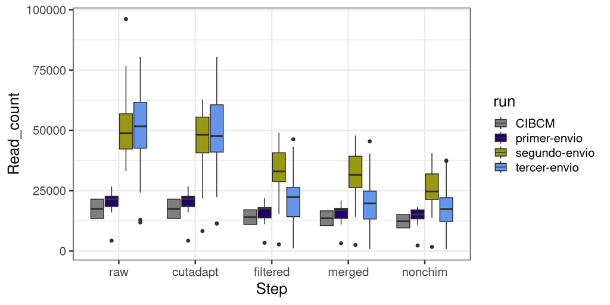

```r
(plot_track <- track_update %>%
    pivot_longer(., cols = c(raw, cutadapt, filtered, merged, nonchim), names_to = "Step",
        values_to = "Read_count") %>%
    dplyr::mutate(Step = fct_relevel(Step, c("raw", "cutadapt", "filtered", "merged",
        "nonchim"))) %>%
    ggplot(aes(x = Step, y = Read_count, fill = run)) + geom_boxplot() + scale_fill_manual(values = c("grey50",
    "#230066", "#999911", "cornflowerblue")) + theme_bw(base_size = 18))
```

### Export files for use in QIIME2

```r
write.table(t(seqtab_nochim), paste0(outputDir,
    "/01_dada2/ITS2_QIIME2seqtab.txt"), sep = "\t",
    row.names = TRUE, col.names = NA, quote = FALSE)
uniquesToFasta(seqtab_nochim, fout = paste0(outputDir,
    "/01_dada2/ITS2-rep-seqs.fna"), ids = colnames(seqtab_nochim))
```

## Session Info

```r
library(details)

sessioninfo::session_info() %>%
    details::details(summary = "Current session info",
        open = FALSE)
```

**Current session info**

```r
─ Session info ───────────────────────────────────────────────────────────────
 setting  value
 version  R version 4.3.2 (2023-10-31)
 os       Linux Mint 21.1
 system   x86_64, linux-gnu
 ui       X11
 language en_US
 collate  en_IN.UTF-8
 ctype    en_IN.UTF-8
 tz       America/Costa_Rica
 date     2023-11-22
 pandoc   2.9.2.1 @ /usr/bin/ (via rmarkdown)

─ Packages ───────────────────────────────────────────────────────────────────
 package              * version   date (UTC) lib source
 Biobase              * 2.62.0    2023-10-24 [1] Bioconductor
 BiocGenerics         * 0.48.0    2023-10-24 [1] Bioconductor
 BiocParallel         * 1.34.2    2023-05-22 [1] Bioconductor
 Biostrings           * 2.70.1    2023-10-25 [1] Bioconductor
 bitops                 1.0-7     2021-04-24 [1] CRAN (R 4.3.0)
 bslib                  0.5.1     2023-08-11 [1] CRAN (R 4.3.1)
 cachem                 1.0.8     2023-05-01 [1] CRAN (R 4.3.0)
 callr                  3.7.3     2022-11-02 [1] CRAN (R 4.3.0)
 cli                    3.6.1     2023-03-23 [1] CRAN (R 4.3.0)
 clipr                  0.8.0     2022-02-22 [1] CRAN (R 4.3.0)
 codetools              0.2-19    2023-02-01 [1] CRAN (R 4.3.0)
 colorspace             2.1-0     2023-01-23 [1] CRAN (R 4.3.0)
 crayon                 1.5.2     2022-09-29 [1] CRAN (R 4.3.0)
 dada2                * 1.28.0    2023-04-25 [1] Bioconductor
 DelayedArray           0.26.3    2023-05-22 [1] Bioconductor
 deldir                 1.0-9     2023-05-17 [1] CRAN (R 4.3.0)
 desc                   1.4.2     2022-09-08 [1] CRAN (R 4.3.0)
 details              * 0.3.0     2022-03-27 [1] CRAN (R 4.3.0)
 devtools             * 2.4.5     2022-10-11 [1] CRAN (R 4.3.0)
 digest                 0.6.33    2023-07-07 [1] CRAN (R 4.3.1)
 dplyr                * 1.1.3     2023-09-03 [1] CRAN (R 4.3.1)
 ellipsis               0.3.2     2021-04-29 [1] CRAN (R 4.3.0)
 evaluate               0.23      2023-11-01 [1] CRAN (R 4.3.2)
 fansi                  1.0.5     2023-10-08 [1] CRAN (R 4.3.1)
 farver                 2.1.1     2022-07-06 [1] CRAN (R 4.3.0)
 fastmap                1.1.1     2023-02-24 [1] CRAN (R 4.3.0)
 forcats              * 1.0.0     2023-01-29 [1] CRAN (R 4.3.0)
 formatR                1.14      2023-01-17 [1] CRAN (R 4.3.0)
 fs                     1.6.3     2023-07-20 [1] CRAN (R 4.3.1)
 generics               0.1.3     2022-07-05 [1] CRAN (R 4.3.0)
 GenomeInfoDb         * 1.38.0    2023-10-24 [1] Bioconductor
 GenomeInfoDbData       1.2.11    2023-10-26 [1] Bioconductor
 GenomicAlignments    * 1.36.0    2023-04-25 [1] Bioconductor
 GenomicRanges        * 1.52.0    2023-04-25 [1] Bioconductor
 ggplot2              * 3.4.4     2023-10-12 [1] CRAN (R 4.3.1)
 glue                   1.6.2     2022-02-24 [1] CRAN (R 4.3.0)
 gtable                 0.3.4     2023-08-21 [1] CRAN (R 4.3.1)
 highr                  0.10      2022-12-22 [1] CRAN (R 4.3.0)
 htmltools              0.5.7     2023-11-03 [1] CRAN (R 4.3.2)
 htmlwidgets            1.6.2     2023-03-17 [1] CRAN (R 4.3.0)
 httpuv                 1.6.12    2023-10-23 [1] CRAN (R 4.3.1)
 httr                   1.4.7     2023-08-15 [1] CRAN (R 4.3.2)
 hwriter                1.3.2.1   2022-04-08 [1] CRAN (R 4.3.0)
 interp                 1.1-4     2023-03-31 [1] CRAN (R 4.3.0)
 IRanges              * 2.36.0    2023-10-24 [1] Bioconductor
 jpeg                   0.1-10    2022-11-29 [1] CRAN (R 4.3.0)
 jquerylib              0.1.4     2021-04-26 [1] CRAN (R 4.3.0)
 jsonlite               1.8.7     2023-06-29 [1] CRAN (R 4.3.1)
 knitr                  1.45      2023-10-30 [1] CRAN (R 4.3.2)
 labeling               0.4.3     2023-08-29 [1] CRAN (R 4.3.1)
 later                  1.3.1     2023-05-02 [1] CRAN (R 4.3.0)
 lattice                0.21-8    2023-04-05 [1] CRAN (R 4.3.0)
 latticeExtra           0.6-30    2022-07-04 [1] CRAN (R 4.3.0)
 lifecycle              1.0.4     2023-11-07 [1] CRAN (R 4.3.2)
 magrittr               2.0.3     2022-03-30 [1] CRAN (R 4.3.0)
 Matrix                 1.5-4.1   2023-05-18 [1] CRAN (R 4.3.0)
 MatrixGenerics       * 1.12.0    2023-04-25 [1] Bioconductor
 matrixStats          * 1.0.0     2023-06-02 [1] CRAN (R 4.3.0)
 memoise                2.0.1     2021-11-26 [1] CRAN (R 4.3.0)
 mime                   0.12      2021-09-28 [1] CRAN (R 4.3.0)
 miniUI                 0.1.1.1   2018-05-18 [1] CRAN (R 4.3.0)
 munsell                0.5.0     2018-06-12 [1] CRAN (R 4.3.0)
 pillar                 1.9.0     2023-03-22 [1] CRAN (R 4.3.0)
 pkgbuild               1.4.2     2023-06-26 [1] CRAN (R 4.3.1)
 pkgconfig              2.0.3     2019-09-22 [1] CRAN (R 4.3.0)
 pkgload                1.3.3     2023-09-22 [1] CRAN (R 4.3.1)
 plyr                 * 1.8.9     2023-10-02 [1] CRAN (R 4.3.1)
 png                    0.1-8     2022-11-29 [1] CRAN (R 4.3.2)
 prettyunits            1.2.0     2023-09-24 [1] CRAN (R 4.3.1)
 processx               3.8.2     2023-06-30 [1] CRAN (R 4.3.1)
 profvis                0.3.8     2023-05-02 [1] CRAN (R 4.3.0)
 promises               1.2.1     2023-08-10 [1] CRAN (R 4.3.1)
 ps                     1.7.5     2023-04-18 [1] CRAN (R 4.3.0)
 purrr                  1.0.2     2023-08-10 [1] CRAN (R 4.3.1)
 R6                     2.5.1     2021-08-19 [1] CRAN (R 4.3.0)
 RColorBrewer           1.1-3     2022-04-03 [1] CRAN (R 4.3.0)
 Rcpp                 * 1.0.11    2023-07-06 [1] CRAN (R 4.3.1)
 RcppParallel           5.1.7     2023-02-27 [1] CRAN (R 4.3.0)
 RCurl                  1.98-1.12 2023-03-27 [1] CRAN (R 4.3.0)
 remotes                2.4.2     2021-11-30 [1] CRAN (R 4.3.0)
 reshape2               1.4.4     2020-04-09 [1] CRAN (R 4.3.0)
 rlang                  1.1.2     2023-11-04 [1] CRAN (R 4.3.2)
 rmarkdown              2.25      2023-09-18 [1] CRAN (R 4.3.1)
 rprojroot              2.0.3     2022-04-02 [1] CRAN (R 4.3.0)
 Rsamtools            * 2.16.0    2023-04-25 [1] Bioconductor
 S4Arrays               1.0.4     2023-05-14 [1] Bioconductor
 S4Vectors            * 0.40.0    2023-10-24 [1] Bioconductor
 sass                   0.4.7     2023-07-15 [1] CRAN (R 4.3.1)
 scales                 1.2.1     2022-08-20 [1] CRAN (R 4.3.0)
 sessioninfo            1.2.2     2021-12-06 [1] CRAN (R 4.3.0)
 shiny                  1.7.5.1   2023-10-14 [1] CRAN (R 4.3.1)
 ShortRead            * 1.58.0    2023-04-25 [1] Bioconductor
 stringi                1.7.12    2023-01-11 [1] CRAN (R 4.3.0)
 stringr              * 1.5.0     2022-12-02 [1] CRAN (R 4.3.0)
 SummarizedExperiment * 1.30.2    2023-06-06 [1] Bioconductor
 tibble                 3.2.1     2023-03-20 [1] CRAN (R 4.3.0)
 tidyr                * 1.3.0     2023-01-24 [1] CRAN (R 4.3.0)
 tidyselect             1.2.0     2022-10-10 [1] CRAN (R 4.3.0)
 urlchecker             1.0.1     2021-11-30 [1] CRAN (R 4.3.0)
 usethis              * 2.2.0     2023-06-06 [1] CRAN (R 4.3.0)
 utf8                   1.2.4     2023-10-22 [1] CRAN (R 4.3.1)
 vctrs                  0.6.4     2023-10-12 [1] CRAN (R 4.3.1)
 withr                  2.5.2     2023-10-30 [1] CRAN (R 4.3.2)
 xfun                   0.41      2023-11-01 [1] CRAN (R 4.3.2)
 xml2                   1.3.5     2023-07-06 [1] CRAN (R 4.3.1)
 xtable                 1.8-4     2019-04-21 [1] CRAN (R 4.3.0)
 XVector              * 0.42.0    2023-10-24 [1] Bioconductor
 yaml                   2.3.7     2023-01-23 [1] CRAN (R 4.3.0)
 zlibbioc               1.48.0    2023-10-24 [1] Bioconductor

 [1] /home/kari/R/x86_64-pc-linux-gnu-library/4.3
 [2] /usr/local/lib/R/site-library
 [3] /usr/lib/R/site-library
 [4] /usr/lib/R/library

──────────────────────────────────────────────────────────────────────────────
```